# HW5

Yasemin Gokdag

January 7, 2019

## HW5

First we read the data and assign names of the first two columns BagClass and BagIs respectively, As distance metic I used euclidean and manhattan distances

First method to be applied is k-medoids with euclidean distance. Details of the code can be found in *Appendix*

ROC curve for k-medoids with euclidean distance is as follows. To assess the performance of the clusters I used a purity measure that would show in which ratio the instances that belong to same bag are clustered the same. This is may not a very good measure, but gives an idea.

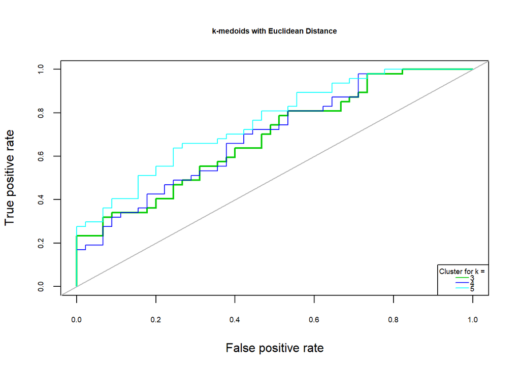

Purity performance of each cluster for k’s are as follows :

```
##                                               x
## 1: Purity metric for k = 3 is 0.750649154589372
## 2: Purity metric for k = 4 is 0.720546497584541
## 3: Purity metric for k = 5 is 0.671203200483092
```

Selected lambda values for fused lasso after 10-fold cross validation and AUC performance for each k is as follows :

Lambda2 Values :

```
##                                                x
## 1:  Lambda2 value for k = 3 is 0.142648970109233
## 2: Lambda2 value for k = 4 is 0.0936284440133888
## 3:  Lambda2 value for k = 5 is 0.504488352678721
```

AUC values :

```
##                                     x
## 1: AUC for k = 3 is 0.684633569739953
## 2: AUC for k = 4 is 0.692671394799054
## 3: AUC for k = 5 is 0.755555555555556
```

Same results will be provided for each methodology. Detailed codes can be found in *Appendix* for each

ROC curve for k-medoids with Manhattan distance

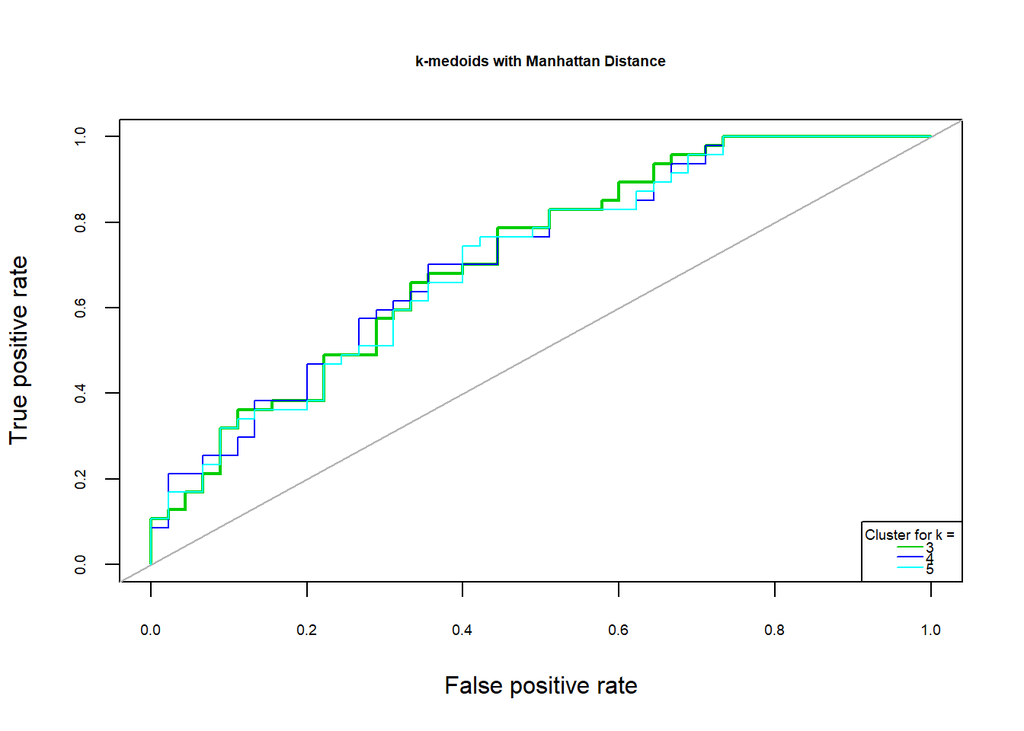

Purity performance of each cluster for k’s are as follows :

```
##                                               x
## 1: Purity metric for k = 3 is 0.737333937198068
## 2: Purity metric for k = 4 is 0.686699879227053
## 3: Purity metric for k = 5 is 0.644852053140097
```

Selected lambda values for fused lasso after 10-fold cross validation and AUC performance for each k is as follows :

Lambda2 Values :

```
##                                                x
## 1: Lambda2 value for k = 3 is 0.0936284440133888
## 2:  Lambda2 value for k = 4 is 0.142648970109233
## 3:  Lambda2 value for k = 5 is 0.142648970109233
```

AUC values :

```
##                                     x
## 1: AUC for k = 3 is 0.715366430260047
## 2: AUC for k = 4 is 0.714893617021277
## 3: AUC for k = 5 is 0.708747044917258
```

ROC for hierarchical clustering with Euclidean distance & ward’s method

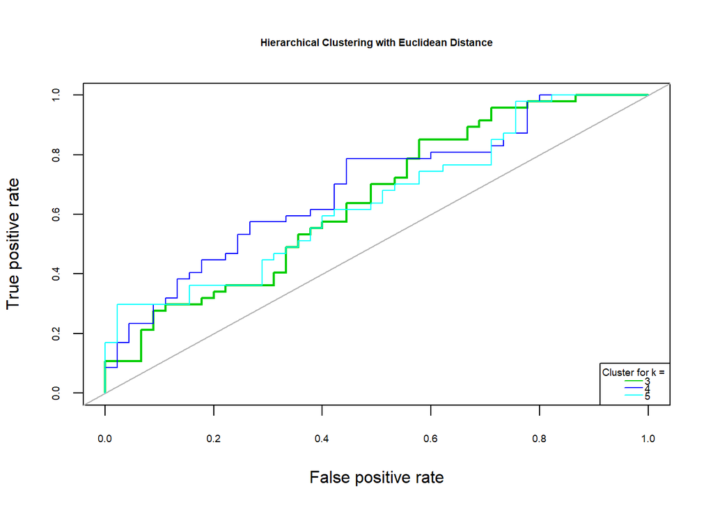

Purity performance of each cluster for k’s are as follows :

```
##                                               x
## 1: Purity metric for k = 3 is 0.824562198067633
## 2: Purity metric for k = 4 is 0.824562198067633
## 3: Purity metric for k = 5 is 0.809646739130435
```

Selected lambda values for fused lasso after 10-fold cross validation and AUC performance for each k is as follows :

Lambda2 Values :

```
##                                               x
## 1:  Lambda2 value for k = 3 is 1.78415937944453
## 2:  Lambda2 value for k = 4 is 1.78415937944453
## 3: Lambda2 value for k = 5 is 0.768620526593735
```

AUC values :

```
##                                     x
## 1: AUC for k = 3 is 0.647281323877068
## 2: AUC for k = 4 is 0.688416075650118
## 3: AUC for k = 5 is 0.643971631205674
```

ROC for hierarchical clustering with Manhattan distance & ward’s method

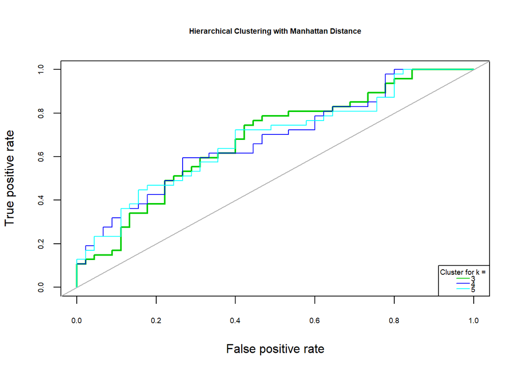

Purity performance of each cluster for k’s are as follows :

```
##                                               x
## 1: Purity metric for k = 3 is 0.829996980676328
## 2: Purity metric for k = 4 is 0.808257850241546
## 3: Purity metric for k = 5 is 0.800347222222222
```

Selected lambda values for fused lasso after 10-fold cross validation and AUC performance for each k is as follows :

Lambda2 Values :

```
##                                               x
## 1: Lambda2 value for k = 3 is 0.217334901670639
## 2: Lambda2 value for k = 4 is 0.504488352678721
## 3:  Lambda2 value for k = 5 is 2.71828182845905
```

AUC values :

```
##                                     x
## 1: AUC for k = 3 is 0.678486997635934
## 2: AUC for k = 4 is 0.677541371158392
## 3: AUC for k = 5 is 0.678014184397163
```

In short we can say that best performance achieved by k-medoids clustering with euclidean distance and k = 5 clusters.

## Appendix

Initialization

```r
rm(list = ls());
require(data.table)
require(kmed)
require(Rfast)
require(ROSE)

setwd('C:/Program Files/R/R-3.5.0/library/lqa/R')
source('cv.lqa.r')
source('lqa.control.r')
source('fused.lasso.r')
source('lambda.check.r')
source('lqa.default.r')
source('lqa.update2.r')
source('get.Amat.r')
source('predict.lqa.r')
source('aic.loss.r')
source('squared.loss.r')
source('dev.loss.r')
source('lasso.r')

musk1 <- read.table(file = "C:/Users/yasemin/Downloads/Musk1.csv", header = F, sep = ",")
musk1 <- as.data.table(musk1)

setnames(musk1,"V1","BagClass")
setnames(musk1,"V2","BagId")

euclidean_dist <- dist(musk1,method = "euclidean")
manhattan_dist <- dist(musk1,method = "manhattan")
```

K-medoids with euclidean distance

```r
#Partition around medoids

plot.new()

k_med_euc <- data.table()
bag_data_euc <- data.table()
k_legend <- data.table()
k_color <- data.table()
auc_euc_medoid <- data.table()
lambda_euc_medoid <- data.table()
purity_euc_med_2 <- data.table()

for (k in c(3,4,5)){

  medoid_euc <- fastkmed(euclidean_dist, ncluster = k, iterate = 100)
  medoid_euc_cluster <- as.data.table(medoid_euc$cluster)
  setnames(medoid_euc_cluster, "V1","cluster")

  euclidean_dist <- as.matrix(euclidean_dist)
  cluster_dist <- as.data.table(euclidean_dist[,medoid_euc$medoid])

  data <- copy(musk1)
  data <- cbind(musk1[,1:2],cluster_dist)
  euc_medoid_bagdata <- data[, lapply(.SD, mean), by=list(BagClass,BagId)]

  purity <- cbind(musk1[,1:2],medoid_euc_cluster)

  purity_matrix <- as.data.table(dcast(purity, BagId ~ cluster, fun  = length ))
  purity_sum <- dcast(purity, BagId ~ . , fun  = length )
  p <- purity_matrix[,2:ncol(purity_matrix)] / purity_sum$.
  purity_euc_med <- sum(apply(p,1,max))/nrow(p)

  purity_euc_med_2 <- rbind(purity_euc_med_2, paste0('Purity metric for k = ' , k , ' is ', purity_euc_med) )


  #generating arbitrary lambda2 sequences
  lambda2=exp (seq (-7, 1, length = 20))
#  print(lambda2) #check what they are
  #parameters to be tried is lambda1 for L1 penalty and lambda2 for L2 (fused lasso penalty)
  #fixing lambda1 to 1, I try to find the optimal lambda2 value from the sequence
  lambdas=list(1,lambda2)

  #run the logistic regression (binomial family for binary classification problem)
  cvFused=cv.lqa(euc_medoid_bagdata$BagClass,euc_medoid_bagdata[,3:ncol(euc_medoid_bagdata)],lambda.candidates = lambdas, intercept = FALSE,
                 family=binomial(), penalty.family=fused.lasso,n.fold=10,loss.func = "dev.loss")

  #predictions
  cvFused$best.obj$fitted.values
  k_legend <- rbind(k_legend,k)
  k_color <- rbind(k_color,k)


  if (k == 3){
    roc.curve(euc_medoid_bagdata$BagClass, cvFused$best.obj$fitted.values, add.roc = FALSE , col = k, main = 'k-medoids with Euclidean Distance', cex.main = 0.6, cex.axis = 0.6  )
      legend("bottomright",  legend = unique(k_legend$x), col = unique(k_color$x), lty = 1  , title = "Cluster for k = ",  xjust =1 , yjust=1, x.intersp = 0.2,y.intersp = 0.6, cex = 0.6)
      auc_euc_medoid <- rbind(auc_euc_medoid,paste0('AUC for k = ',k,' is ', auc(euc_medoid_bagdata$BagClass, cvFused$best.obj$fitted.values)))

  } else
  {
    roc.curve(euc_medoid_bagdata$BagClass, cvFused$best.obj$fitted.values, add.roc = TRUE , col = k , main = 'k-medoids with Euclidean Distance', cex.main = 0.6, cex.axis = 0.6  )
      legend("bottomright",  legend = unique(k_legend$x), col = unique(k_color$x), lty = 1  , title = "Cluster for k = ",  xjust =1 , yjust=1, x.intersp = 0.2,y.intersp = 0.6, cex = 0.6)
      auc_euc_medoid <- rbind(auc_euc_medoid,paste0('AUC for k = ',k,' is ', auc(euc_medoid_bagdata$BagClass, cvFused$best.obj$fitted.values)))

      }
  lambda_euc_medoid <- rbind(lambda_euc_medoid,paste0('Lambda2 value for k = ',k,' is ',cvFused$lambda.opt[2]))

}
```

K-medoids with manhattan distance

```r
plot.new()
#Manhattan distance
k_legend <- data.table()
k_color <- data.table()
auc_man_medoid <- data.table()
lambda_man_medoid <- data.table()
k_med_man <- data.table()
bag_data_man <- data.table()
purity_man_med_2 <- data.table()

for (k in c(3,4,5)){

  medoid_man <- fastkmed(manhattan_dist, ncluster = k, iterate = 100)
  medoid_man_cluster <- as.data.table(medoid_man$cluster)
  setnames(medoid_man_cluster, "V1","cluster")

  manhattan_dist <- as.matrix(manhattan_dist)
  cluster_dist <- as.data.table(manhattan_dist[,medoid_man$medoid])

  data <- copy(musk1)
  data <- cbind(musk1[,1:2],cluster_dist)
  man_medoid_bagdata <- data[, lapply(.SD, mean), by=list(BagClass,BagId)]

  purity <- cbind(musk1[,1:2],medoid_man_cluster)

  purity_matrix <- as.data.table(dcast(purity, BagId ~ cluster, fun  = length ))
  purity_sum <- dcast(purity, BagId ~ . , fun  = length )
  p <- purity_matrix[,2:ncol(purity_matrix)] / purity_sum$.
  purity_man_med <- sum(apply(p,1,max))/nrow(p)

  purity_man_med_2 <- rbind(purity_man_med_2, paste0('Purity metric for k = ' , k , ' is ',purity_man_med))

  #generating arbitrary lambda2 sequences
  lambda2=exp (seq (-7, 1, length = 20))
  #  print(lambda2) #check what they are
  #parameters to be tried is lambda1 for L1 penalty and lambda2 for L2 (fused lasso penalty)
  #fixing lambda1 to 1, I try to find the optimal lambda2 value from the sequence
  lambdas=list(1,lambda2)

  #run the logistic regression (binomial family for binary classification problem)
  cvFused=cv.lqa(man_medoid_bagdata$BagClass,man_medoid_bagdata[,3:ncol(man_medoid_bagdata)],lambda.candidates = lambdas, intercept = FALSE,
                 family=binomial(), penalty.family=fused.lasso,n.fold=10,loss.func = "dev.loss")

  #predictions
  cvFused$best.obj$fitted.values
  k_legend <- rbind(k_legend,k)
  k_color <- rbind(k_color,k)

  if (k == 3){
    roc.curve(man_medoid_bagdata$BagClass, cvFused$best.obj$fitted.values, add.roc = FALSE , col = k, main = 'k-medoids with Manhattan Distance', cex.main = 0.6, cex.axis = 0.6  )
    legend("bottomright",  legend = unique(k_legend$x), col = unique(k_color$x), lty = 1  , title = "Cluster for k = ",  xjust =1 , yjust=1, x.intersp = 0.2,y.intersp = 0.6, cex = 0.6)
    auc_man_medoid <- rbind(auc_man_medoid,paste0('AUC for k = ',k,' is ', auc(man_medoid_bagdata$BagClass, cvFused$best.obj$fitted.values)))

  } else
  {
    roc.curve(man_medoid_bagdata$BagClass, cvFused$best.obj$fitted.values, add.roc = TRUE , col = k , main = 'k-medoids with Manhattan Distance', cex.main = 0.6, cex.axis = 0.6  )
    legend("bottomright",  legend = unique(k_legend$x), col = unique(k_color$x), lty = 1  , title = "Cluster for k = ",  xjust =1 , yjust=1, x.intersp = 0.2,y.intersp = 0.6, cex = 0.6)
    auc_man_medoid <- rbind(auc_man_medoid,paste0('AUC for k = ',k,' is ', auc(man_medoid_bagdata$BagClass, cvFused$best.obj$fitted.values)))

  }
  lambda_man_medoid <- rbind(lambda_man_medoid,paste0('Lambda2 value for k = ',k,' is ',cvFused$lambda.opt[2]))
}
```

Hierarchical clustering with euclidean distance

```r
hier_euc <- data.table()
bag_data_hier_euc <- data.table()
plot.new()
#Manhattan distance
k_legend <- data.table()
k_color <- data.table()
auc_euc_hier <- data.table()
lambda_euc_hier <- data.table()
purity_hier_euc <- data.table()

for (k in (3:5)){
  hier <- hclust(as.dist(euclidean_dist),method="ward.D2")
  hier <- cutree(hier, k = k )
  hier_data <- copy(musk1)
  #Add clusters to data
  hier_data <- cbind(musk1, hier)

  #Calcualate mean instance for each cluster
  hier_data_centroids <- hier_data[,3:ncol(hier_data)][, lapply(.SD,mean), by = hier]
  hier_dist <- rbind(hier_data_centroids[,2:ncol(hier_data_centroids)], musk1[,3:ncol(musk1)])

  hier_dist_2 <- dist(hier_dist,method = "euclidean")
  hier_dist_2 <- as.matrix(hier_dist_2)
  hier_cluster_dist <- t(hier_dist_2[(nrow(musk1)+1):nrow(hier_dist_2),1:nrow(musk1)])

  hier_data_2 <- cbind(musk1[,1:2],hier_cluster_dist)
  hier_bagdata <- hier_data_2[, lapply(.SD, mean), by=list(BagClass,BagId)]

  class_hier <- hier_bagdata$BagClass
  #bagdata <- hier_bagdata[,2:ncol(hier_bagdata)]

  purity <- cbind(musk1[,1:2],hier_data$hier)

  purity_matrix <- as.data.table(dcast(purity, BagId ~ hier, fun  = length ))
  purity_sum <- dcast(purity, BagId ~ . , fun  = length )
  p <- purity_matrix[,2:ncol(purity_matrix)] / purity_sum$.
  purity_2 <- sum(apply(p,1,max))/nrow(p)

  purity_hier_euc <- rbind(purity_hier_euc , paste0('Purity metric for k = ' , k , ' is ',purity_2 ))


  #generating arbitrary lambda2 sequences
  lambda2=exp (seq (-7, 1, length = 20))
  #  print(lambda2) #check what they are
  #parameters to be tried is lambda1 for L1 penalty and lambda2 for L2 (fused lasso penalty)
  #fixing lambda1 to 1, I try to find the optimal lambda2 value from the sequence
  lambdas=list(1,lambda2)

  #run the logistic regression (binomial family for binary classification problem)
  cvFused=cv.lqa(hier_bagdata$BagClass,hier_bagdata[,3:ncol(hier_bagdata)],lambda.candidates = lambdas, intercept = FALSE,
                 family=binomial(), penalty.family=fused.lasso,n.fold=10,loss.func = "dev.loss")

  k_legend <- rbind(k_legend,k)
  k_color <- rbind(k_color,k)
  if (k == 3){
    roc.curve(hier_bagdata$BagClass, cvFused$best.obj$fitted.values, add.roc = FALSE , col = k, main = 'Hierarchical Clustering with Euclidean Distance', cex.main = 0.6, cex.axis = 0.6  )
    legend("bottomright",  legend = unique(k_legend$x), col = unique(k_color$x), lty = 1  , title = "Cluster for k = ",  xjust =1 , yjust=1, x.intersp = 0.2,y.intersp = 0.6, cex = 0.6)
    auc_euc_hier <- rbind(auc_euc_hier,paste0('AUC for k = ',k,' is ', auc(hier_bagdata$BagClass, cvFused$best.obj$fitted.values)))

  } else
  {
    roc.curve(hier_bagdata$BagClass, cvFused$best.obj$fitted.values, add.roc = TRUE , col = k , main = 'Hierarchical Clustering with Euclidean Distance', cex.main = 0.6, cex.axis = 0.6  )
    legend("bottomright",  legend = unique(k_legend$x), col = unique(k_color$x), lty = 1  , title = "Cluster for k = ",  xjust =1 , yjust=1, x.intersp = 0.2,y.intersp = 0.6, cex = 0.6)
    auc_euc_hier <- rbind(auc_euc_hier,paste0('AUC for k = ',k,' is ', auc(hier_bagdata$BagClass, cvFused$best.obj$fitted.values)))

  }
  lambda_euc_hier <- rbind(lambda_euc_hier,paste0('Lambda2 value for k = ',k,' is ',cvFused$lambda.opt[2]))

}
```

Hierarchical clustering with manhattan distance

```r
#Hierarchical with manhattan distance
plot.new()
#Manhattan distance
k_legend <- data.table()
k_color <- data.table()
auc_man_hier <- data.table()
lambda_man_hier <- data.table()
hier_man <- data.table()
bag_data_hier_man <- data.table()
purity_hier_man <- data.table()

rm(hier);
rm(hier_data);
rm(hier_dist);
rm(hier_data_2);


for (k in (3:5)){
  hier <- hclust(as.dist(manhattan_dist),method="ward.D2")
  hier <- cutree(hier, k = k )
  hier_data <- copy(musk1)
  #Add clusters to data
  hier_data <- cbind(musk1, hier)

  #Calcualate mean instance for each cluster
  hier_data_centroids <- hier_data[,3:ncol(hier_data)][, lapply(.SD,mean), by = hier]
  hier_dist <- rbind(hier_data_centroids[,2:ncol(hier_data_centroids)], musk1[,3:ncol(musk1)])

  hier_dist_2 <- dist(hier_dist,method = "manhattan")
  hier_dist_2 <- as.matrix(hier_dist_2)
  hier_cluster_dist <- t(hier_dist_2[(nrow(musk1)+1):nrow(hier_dist_2),1:nrow(musk1)])

  hier_data_2 <- cbind(musk1[,1:2],hier_cluster_dist)
  bag_data_hier_man <- hier_data_2[, lapply(.SD, mean), by=list(BagClass,BagId)]

  class_hier <- bag_data_hier_man$BagClass
  bagdata <- bag_data_hier_man[,2:ncol(bag_data_hier_man)]


  purity <- cbind(musk1[,1:2],hier_data$hier)

  purity_matrix <- as.data.table(dcast(purity, BagId ~ hier, fun  = length ))
  purity_sum <- dcast(purity, BagId ~ . , fun  = length )
  p <- purity_matrix[,2:ncol(purity_matrix)] / purity_sum$.
  purity_2 <- sum(apply(p,1,max))/nrow(p)

  purity_hier_man <- rbind(purity_hier_man, paste0('Purity metric for k = ' , k , ' is ',purity_2 ))


  #generating arbitrary lambda2 sequences
  lambda2=exp(seq (-7, 1, length = 20))
  #  print(lambda2) #check what they are
  #parameters to be tried is lambda1 for L1 penalty and lambda2 for L2 (fused lasso penalty)
  #fixing lambda1 to 1, I try to find the optimal lambda2 value from the sequence
  lambdas=list(1,lambda2)

  #run the logistic regression (binomial family for binary classification problem)
  cvFused=cv.lqa(bag_data_hier_man$BagClass,bag_data_hier_man[,3:ncol(bag_data_hier_man)],lambda.candidates = lambdas, intercept = FALSE,
                 family=binomial(), penalty.family=fused.lasso,n.fold=10,loss.func = "dev.loss")

  #predictions
  cvFused$best.obj$fitted.values
  k_legend <- rbind(k_legend,k)
  k_color <- rbind(k_color,k)

  if (k == 3){
    roc.curve(bag_data_hier_man$BagClass, cvFused$best.obj$fitted.values, add.roc = FALSE , col = k, main = 'Hierarchical Clustering with Manhattan Distance', cex.main = 0.6, cex.axis = 0.6  )
    legend("bottomright",  legend = unique(k_legend$x), col = unique(k_color$x), lty = 1  , title = "Cluster for k = ",  xjust =1 , yjust=1, x.intersp = 0.2,y.intersp = 0.6, cex = 0.6)
    auc_man_hier <- rbind(auc_man_hier,paste0('AUC for k = ',k,' is ', auc(bag_data_hier_man$BagClass, cvFused$best.obj$fitted.values)))

  } else
  {
    roc.curve(bag_data_hier_man$BagClass, cvFused$best.obj$fitted.values, add.roc = TRUE , col = k , main = 'Hierarchical Clustering with Manhattan Distance', cex.main = 0.6, cex.axis = 0.6  )
    legend("bottomright",  legend = unique(k_legend$x), col = unique(k_color$x), lty = 1  , title = "Cluster for k = ",  xjust =1 , yjust=1, x.intersp = 0.2,y.intersp = 0.6, cex = 0.6)
    auc_man_hier <- rbind(auc_man_hier,paste0('AUC for k = ',k,' is ', auc(bag_data_hier_man$BagClass, cvFused$best.obj$fitted.values)))

  }
  lambda_man_hier <- rbind(lambda_man_hier,paste0('Lambda2 value for k = ',k,' is ',cvFused$lambda.opt[2]))

}
```